# Week10a Cow diets

Emily Simmonds

Answers in purple

These answers are like those on a grading scheme for an exam. You should be able to score your own work or you could swap with someone else to grade each other’s. Hopefully this can give an idea of how marks are assigned in exams.

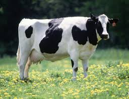

* credit: commons.wikimedia

These data are from an experiment on cows. Cows were split into 6 groups, each given a different diet treatment. Here you will look at how these different treatments influenced the dry matter intake (DMI) of the cows.

You can find the data [here](https://www.math.ntnu.no/emner/ST2304/2020v/Week09/cowdata.csv) it is a .csv with a header.

**Important! When you import the data it is important to make sure it is in the right format. Here you need Treatment to be a factor and Baseline to be numeric. See code below.**

```r
cowdata <- read.csv("https://www.math.ntnu.no/emner/ST2304/2020v/Week09/cowdata.csv", header=TRUE)

# str() checks the data structure
str(cowdata)
```

```
## 'data.frame':    57 obs. of  3 variables:
##  $ Treatment: int  4 5 4 3 5 2 1 3 3 1 ...
##  $ Baseline : chr  "22.4757" "24.5157" "22.1100" "18.9529" ...
##  $ DMI      : num  24.5 26.8 25.4 27.7 17.1 ...
```

```r
# we can see that the variables are not the right format
# so we fix it
cowdata$Treatment <- as.factor(cowdata$Treatment)
cowdata$Baseline <- as.numeric(cowdata$Baseline)

# now check again
str(cowdata)
```

```
## 'data.frame':    57 obs. of  3 variables:
##  $ Treatment: Factor w/ 6 levels "1","2","3","4",..: 4 5 4 3 5 2 1 3 3 1 ...
##  $ Baseline : num  22.5 24.5 22.1 19 20.1 ...
##  $ DMI      : num  24.5 26.8 25.4 27.7 17.1 ...
```

The columns in the dataframe are:

- DMI = the dry matter intake during the experiment (grams)
- Baseline = the baseline dry matter intake before the experiment (grams)
- Treatment = the diet treatment group (1 to 6)

**You want to find out how diet treatment influenced dry matter intake while controlling for the baseline intake of each cow.**

1. What model will you use to answer this? (1 mark)

1 point for any of: linear model, regression, ancova. No points for anova or t-test. There is because there is one categorical and one continuous explanatory here. A linear model that could be viewed as an ancova is maybe most correct but the maths is the same as a regression so that is allowed too.

2. What type of variables do you have and which are response or explanatory? (3 marks)

1 point for each of: DMI = response, continuous. Treatment = explanatory, categorical. Baseline = explanatory, continuous.

We have given code to run a model for the data below. Think about what type of model is being run? It is good practice to consider if you would have chosen the same one.

```r
# Model 1
model1 <- lm(DMI ~ Treatment+Baseline, data = cowdata)

coef(model1)
```

```
## (Intercept)  Treatment2  Treatment3  Treatment4  Treatment5  Treatment6
##  15.5566663  -0.2420337  -1.0015958  -1.3042739  -2.3390966  -1.6270854
##    Baseline
##   0.4998618
```

```r
confint(model1)
```

```
##                  2.5 %     97.5 %
## (Intercept) 11.0734299 20.0399026
## Treatment2  -2.2612061  1.7771386
## Treatment3  -3.1054750  1.1022834
## Treatment4  -3.3179503  0.7094025
## Treatment5  -4.4809290 -0.1972641
## Treatment6  -3.6633444  0.4091737
## Baseline     0.2933972  0.7063264
```

3. Interpret the output of the model. What does it tell you about the effect of diet on DMI? (5 marks)

1 mark for: Intercept is intercept of the model line (Y value when Baseline = 0) for Treatment group 1. 1 mark for: effect of Baseline intake is positive (cows that ate more before eat more during the experiment coefficient estimate of 0.5 95% CI = 0.29 to 0.71 grams per gram). 1 mark for: the effect of Baseline intake is the same for all groups. 1 mark for: all treatments 2-6 seem to have a negative effect relative to Treatment group 1 (mention the actual estimate of effect). 1 mark for: the confidence intervals cross 0 for groups 2,3,4, and 6 so the effects do not have a clearly distinguishable direction of effect. Only group 5 has a distinguishable difference from group 1 estimate = -2.34, (95% CI -4.48 to -0.2grams). **To get each mark you should mention confidence intervals and the coefficient estimate for specific effects.**

Below is the code to make some graphs to check the model fit.

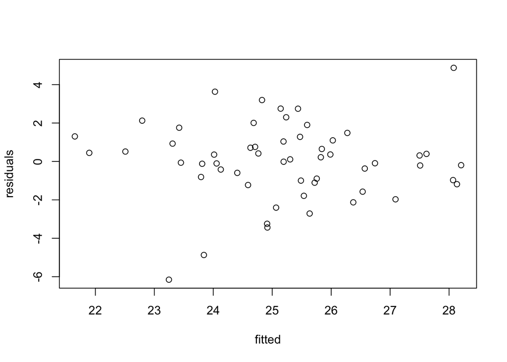

```r
# Graph 1

residuals <- residuals(model1)
fitted <- fitted(model1)
plot(fitted, residuals)
```

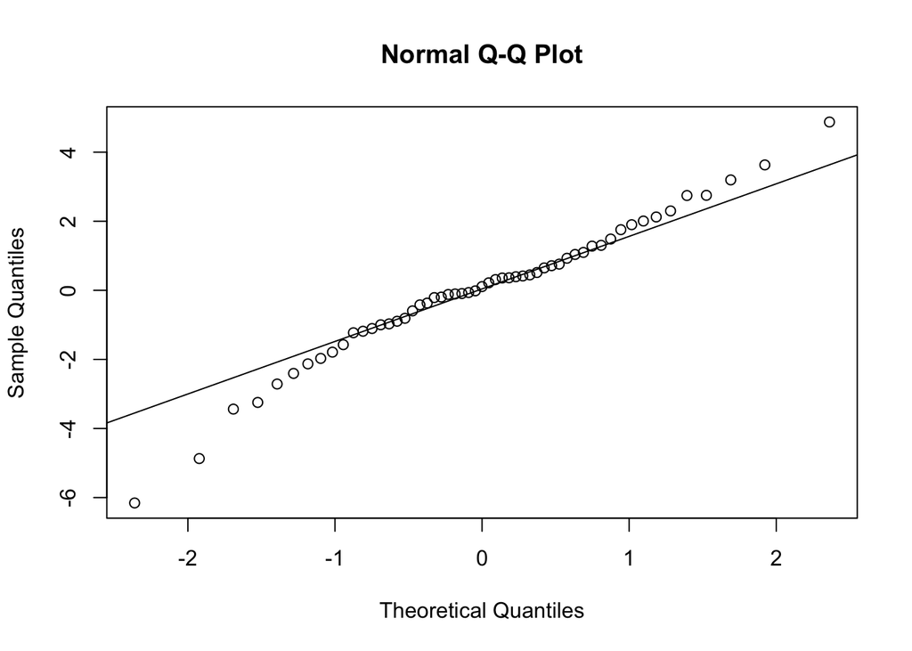

```r
qqnorm(residuals)
qqline(residuals)
```

4. What are the assumptions of the model? (5 marks)

1 mark each for: linearity, equal variance (homoscedasticity - spelling not counted!!), independence of data points, no outliers, normality of residuals. Could also include mean of residuals = 0.

5. Are the assumptions met? Reference which plot you use to decide and why you make the choice. (6 marks)

3 marks for: Yes - equal variance, tested using residuals vs fitted plot and there is no structure there. Also 3 marks for: Yes - normality of residuals, tested using normal qq, fall mostly along the line, some deviation at edges. For both, could argue that assumptions are not met as there is some deviation from perfection, but it is not strong. Would need to say exactly where the deviations are e.g. for low values in the normal qq plot and slightly higher variance at fitted values 23 and 24 in the residuals vs fitted plot. Could suggest a slight curve in the residuals vs fitted as more points above 0 on left than right of graph.

6. What other plot might you also want for checking assumptions? (1 mark)

1 mark: cook’s distance. Scale and leverage could also be accepted but would be unexpected as an answer.

Here is code for another model on the same data.

```r
# Model 2
model2 <- lm(DMI ~ Treatment*Baseline, data = cowdata)

coef(model2)
```

```
##         (Intercept)          Treatment2          Treatment3          Treatment4
##         14.96397551          1.83547186         -4.57792728          4.53811818
##          Treatment5          Treatment6            Baseline Treatment2:Baseline
##         -7.35426532         -0.21405539          0.52882628         -0.09883937
## Treatment3:Baseline Treatment4:Baseline Treatment5:Baseline Treatment6:Baseline
##          0.15638806         -0.28162245          0.22723154         -0.06631897
```

```r
confint(model2)
```

```
##                           2.5 %     97.5 %
## (Intercept)          -0.4488745 30.3768256
## Treatment2          -16.7418094 20.4127532
## Treatment3          -22.9288747 13.7730201
## Treatment4          -13.9556395 23.0318758
## Treatment5          -29.2072749 14.4987443
## Treatment6          -18.7696470 18.3415362
## Baseline             -0.2205945  1.2782471
## Treatment2:Baseline  -0.9908036  0.7931248
## Treatment3:Baseline  -0.7116666  1.0244427
## Treatment4:Baseline  -1.1755869  0.6123420
## Treatment5:Baseline  -0.8011423  1.2556053
## Treatment6:Baseline  -0.9489395  0.8163016
```

7. How is this model different to the first one? (1 mark)

1 mark: this model now has an interaction between treatment and baseline intake.

9. Which model do you prefer, why? (4 marks)

1 mark for: I prefer model 1. 1 mark for: because it had clearer estimates of some effects. 1 mark for: model 2 could not identify the direction of any effects (confidence intervals spanning 0). 1 mark for: as none of the interaction terms had a clear direction, I could conclude the interaction was not needed. I do not think you would be able to justify choosing model 2.